Skip to main content

# Sex hormone-binding globulin and skeletal muscle mass in midlife women

- Show All Code
- Hide All Code
- View Source

Analysis report for the PLOS ONE manuscript · SWAN visit 10 (2006 to 2008)

**Code: setup, and checks that the statements of the text hold in the data**

```r
source("_common.R")
a1 <- SE$A1; a5 <- SE$A5; b1 <- SE$B1
st <- rows(S$strata)
cell <- function(w, t) st[st$waist_tertile == w & st$shbg_tertile == t, ]
gap  <- function(w) cell(w, "Lowest")$mean_smm - cell(w, "Highest")$mean_smm      # lowest minus highest tertile of SHBG, kg
gw   <- sapply(c("Lowest", "Middle", "Highest"), gap)
other <- sapply(paste0("B", 2:8), function(k) pct(SE[[k]]$ratio))            # one covariate other than waist removed
# statements made in the text must hold in the data
stopifnot(a1$p < 0.001, a5$p > 0.05, b1$p < 0.001, all(sapply(paste0("B", 2:8), function(k) SE[[k]]$p) > 0.05),
          SE$C1$p > 0.05, SE$C2$p > 0.05, SE$C3$p < 0.001, gap("All women") > 1.5, all(gw >= 0 & gw < 0.7))
```

Working version of 18 November 2026. This report documents the analysis behind the manuscript *Sex hormone-binding globulin and skeletal muscle mass in midlife women: a cross-sectional analysis of the Study of Women’s Health Across the Nation (SWAN)* by Carla Basualto-Alarcón, Amaru Agüero, Manuel Estrada and Luis Toro.

## The question

Sex hormone-binding globulin (SHBG) carries testosterone and estradiol in plasma. Higher SHBG has been related to lower lean or muscle mass in post-menopausal women, which would make it a candidate marker of muscle health.

**The gap.** SHBG falls with adiposity and absolute muscle mass rises with body size, so an inverse association between the two could arise from adiposity alone. It was unclear to what extent the association is independent of body size, and how much the answer depends on the way body size is measured. Most of the evidence also comes from post-menopausal and older women.

**What this analysis does.** It estimates the association between serum SHBG and skeletal muscle mass in midlife women with adjustment for height and central adiposity, and shows how the estimate depends on each covariate of the model.

## The data, before any model

Mean skeletal muscle mass was 2.0 kg lower in the highest than in the lowest tertile of SHBG. Within tertiles of waist circumference the same difference was 0.0, 0.2 and 0.6 kg. Women with low SHBG were concentrated in the highest tertile of waist circumference (52% of the lowest tertile of SHBG, against 14% of the highest).

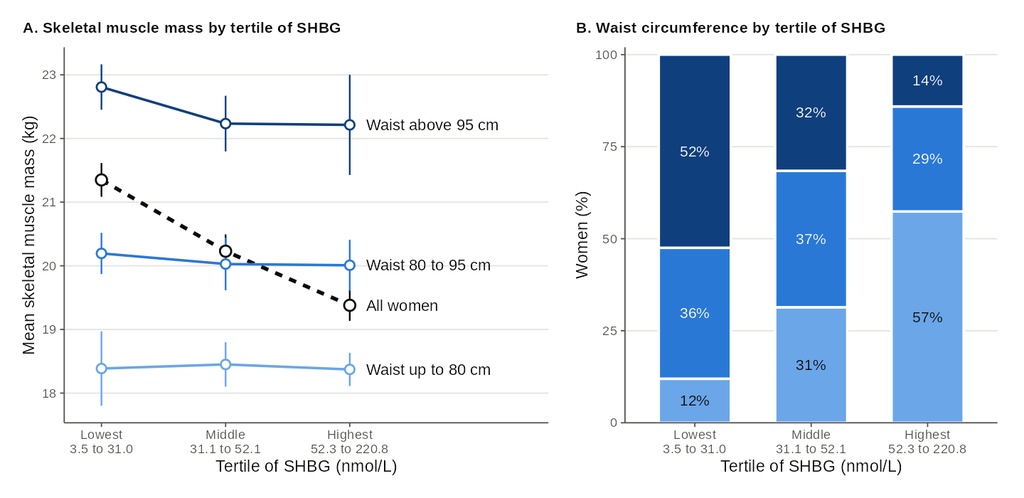

(A) Unadjusted mean skeletal muscle mass, with 95% confidence intervals, by tertile of SHBG, in all women (dashed line) and within each tertile of waist circumference (solid lines). (B) Percentage of the women in each tertile of SHBG who were in the lowest (bottom), middle and highest (top) tertile of waist circumference. Fig 1 of the manuscript.

## Main findings

1,693

women analyzed

of 2,245 examined at visit 10, aged 51 to 63 years

−4.28%

muscle mass per doubling of SHBG, without adjustment

95% CI −5.05 to −3.51

−0.40%

per doubling of SHBG in the primary model

95% CI −1.05 to 0.25; P = 0.223; about −0.08 kg

−3.50%

primary model without waist circumference

95% CI −4.14 to −2.86; the only covariate that matters

Women with higher SHBG had lower skeletal muscle mass, but the association was **not independent of body size**. After adjustment for height, waist circumference and the other covariates, the difference per doubling of SHBG was compatible with no association. Waist circumference was the only covariate whose removal changed the estimate appreciably; without any of the others it stayed between −0.53% and −0.08%. The result was the same with body mass index or weight as the measure of body size, but not when fat mass from the same impedance measurement replaced waist circumference (−2.49% (95% CI −3.16 to −1.82)). SHBG appears to reflect adiposity rather than muscle mass.

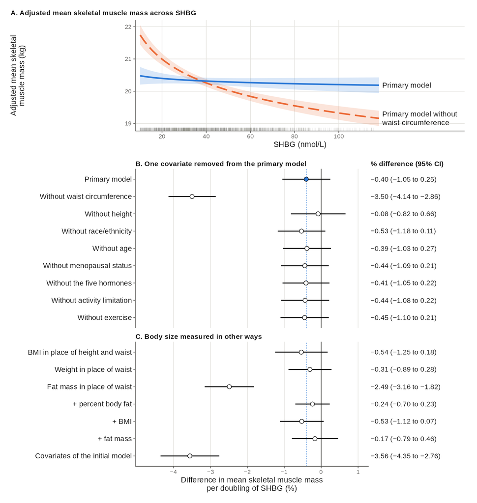

(A) Adjusted mean skeletal muscle mass across SHBG in the primary model (solid line) and in the primary model without waist circumference (dashed line); means are standardized to the covariate distribution of the sample and bands are 95% confidence intervals. (B) Percent difference in mean skeletal muscle mass per doubling of SHBG when one covariate is removed from the primary model. (C) The same difference when body size is measured in other ways. The filled point and the dotted line mark the primary model. Fig 2 of the manuscript.

The primary model was revised on 17 November 2026, after the results of an initial model were known. The initial model, which had percent body fat as the only measure of body composition, gave −1.06% per 10 nmol/L of SHBG (95% CI −1.34 to −0.79). Both models are reported; see Model definition.

## How to read this report

Data and sample

Source, variables and units, who was analyzed, missing values, characteristics of the sample.

Model definition

The mathematical definition of the primary model, the quantities reported, the initial model and every sensitivity model.

Primary model

Ratios of means, coefficients, adjusted means and the comparison across menopausal status.

Sensitivity analyses

The role of each covariate, other measures of body size, scaling, specification, sample restrictions, shape, the initial model, SHBG as the outcome.

Diagnostics and model choice

Residuals, influence, collinearity, and whether the gamma model is an adequate choice.

Reproducibility

How to rerun everything, what each script produces, the code of every script, software versions, audit of the first submission.

## Data and code

The analysis uses the public-use file of SWAN visit 10 (ICPSR study 32961, version 2, [doi: 10.3886/ICPSR32961.v2](https://doi.org/10.3886/ICPSR32961.v2)). The code is in the folder [`analysis/`](https://github.com/AmaruSimonAgueroJimenez/SWAN/tree/main/analysis) of the repository and reproduces every table, figure and number with one command, `Rscript analysis/run_all.R`.

The code is also on these pages, folded. *Code* above a table shows how it was built, and the *Code* menu at the top of each page shows or hides all the code of the page and gives its source. The scripts of the pipeline that compute the numbers are at the end of each page and, all of them, on the page Reproducibility.

The exploratory analysis that preceded this work is kept unchanged as Exploratory analysis (2025). It is not the analysis reported in the manuscript.